# Assignment 4 - Multiple Linear Regression

Aristide N. - 20252MBI042

November 2026

## Research question

Do country population characteristics and continent help explain differences in per-capita CO2 emissions? This analysis uses multiple linear regression to study the association between 2019 CO2 emissions per person and population size, population density, annual population growth, and continent.

The analysis is observational: its results describe associations and do not show that population characteristics cause emissions to change.

## Data and preparation

The analysis combines the repository’s `CO2_emission.csv` and `world_population.csv` files using their three-letter country codes. The emissions file contains CO2 emissions in metric tons per person and has two columns labeled 2019; the first is used. Population size, density, growth rate, and continent come from the population file. Rows missing any analysis variable, and rows with non-positive values for a logged variable, are excluded.

```r
population <- read.csv("datasets/world_population.csv", check.names = FALSE)
emissions_raw <- read.csv("datasets/CO2_emission.csv", check.names = FALSE)

year_2019 <- which(names(emissions_raw) == "2019")
if (length(year_2019) == 0) {
  stop("The emissions dataset does not contain a 2019 column.")
}
if (length(year_2019) > 1 &&
    !isTRUE(all.equal(
      emissions_raw[[year_2019[1]]],
      emissions_raw[[year_2019[2]]],
      check.attributes = FALSE
    ))) {
  stop("The duplicate 2019 emissions columns do not match.")
}

if (anyDuplicated(population$CCA3) || anyDuplicated(emissions_raw$country_code)) {
  stop("Country codes must be unique within each dataset.")
}

population_for_join <- data.frame(
  code = population$CCA3,
  population_2022 = population[["2022 Population"]],
  density = population[["Density (per km²)"]],
  growth_factor = population[["Growth Rate"]],
  continent = population$Continent
)
emissions_for_join <- data.frame(
  code = emissions_raw$country_code,
  co2_per_capita_2019 = emissions_raw[[year_2019[1]]]
)

joined <- merge(population_for_join, emissions_for_join, by = "code")
analysis_data <- joined[
  complete.cases(joined) &
    joined$population_2022 > 0 &
    joined$density > 0 &
    joined$co2_per_capita_2019 > 0,
]
analysis_data$continent <- relevel(
  factor(analysis_data$continent),
  ref = "Africa"
)
analysis_data$log_co2 <- log(analysis_data$co2_per_capita_2019)
analysis_data$log_population <- log(analysis_data$population_2022)
analysis_data$log_density <- log(analysis_data$density)
analysis_data$growth_percent <- (analysis_data$growth_factor - 1) * 100

if (nrow(analysis_data) == 0) {
  stop("No complete, positive observations are available for the model.")
}

model <- lm(
  log_co2 ~ log_population + log_density + growth_percent + continent,
  data = analysis_data
)
model_summary <- summary(model)
```

The model contains 191 countries. Its response is the natural logarithm of 2019 per-capita emissions. Natural logarithms are used for emissions, population size, and density because these measures span wide ranges and emissions are right-skewed. The growth-rate variable is expressed as an annual percentage (for example, a growth factor of 1.02 is 2%).

## Model

The fitted model is:

$$\log(\text{CO2 per capita}) =
\beta_0 + \beta_1\log(\text{population}) +
\beta_2\log(\text{density}) + \beta_3(\text{growth percent}) +
\text{continent effects} + \epsilon.$$

Africa is the reference continent. Each coefficient estimates the association with emissions while holding the other variables in the model constant.

```r
coefficient_table <- as.data.frame(coef(model_summary))
coefficient_table$term <- rownames(coefficient_table)
confidence_intervals <- confint(model)
coefficient_table$lower_95 <- confidence_intervals[
  coefficient_table$term, 1
]
coefficient_table$upper_95 <- confidence_intervals[
  coefficient_table$term, 2
]
rownames(coefficient_table) <- NULL
names(coefficient_table) <- c(
  "Estimate", "Std. error", "t value", "p value", "Term",
  "95% CI lower", "95% CI upper"
)
coefficient_table <- coefficient_table[
  , c("Term", "Estimate", "Std. error", "95% CI lower", "95% CI upper", "p value")
]

knitr::kable(
  coefficient_table,
  digits = 3,
  caption = "Multiple regression coefficients and 95% confidence intervals"
)
```

Multiple regression coefficients and 95% confidence intervals

| Term | Estimate | Std. error | 95% CI lower | 95% CI upper | p value |
| --- | --- | --- | --- | --- | --- |
| (Intercept) | 1.511 | 0.718 | 0.094 | 2.927 | 0.037 |
| log_population | -0.073 | 0.039 | -0.151 | 0.005 | 0.066 |
| log_density | -0.135 | 0.059 | -0.251 | -0.018 | 0.024 |
| growth_percent | -0.248 | 0.062 | -0.370 | -0.126 | 0.000 |
| continentAsia | 1.794 | 0.222 | 1.356 | 2.232 | 0.000 |
| continentEurope | 1.980 | 0.239 | 1.508 | 2.452 | 0.000 |
| continentNorth America | 1.371 | 0.276 | 0.827 | 1.915 | 0.000 |
| continentOceania | 0.992 | 0.339 | 0.324 | 1.660 | 0.004 |
| continentSouth America | 1.169 | 0.342 | 0.493 | 1.844 | 0.001 |

The model explains 50.9% of the variation in log emissions (adjusted $R^2$ = 0.487). The predictors are statistically associated with the response overall ($F$ = 23.59, $p$ = <2e-16).

### Interpreting the coefficients

Because both emissions and population size are logged, the population coefficient is an elasticity: a 1% increase in population is associated with approximately a -0.07% change in per-capita emissions, conditional on the other predictors. This association is not statistically significant at the 5% level ($p$ = 0.066), so these data do not provide clear evidence of an independent population-size association after adjustment.

Likewise, a 1% increase in population density is associated with an approximate -0.13% change in per-capita emissions, holding the remaining variables constant. The estimated association is negative and statistically significant at the 5% level ($p$ = 0.024).

For annual growth, a one-percentage-point increase is associated with an estimated -22.0% change in per-capita emissions, with other predictors held constant. The estimated association is negative ($p$ = 8.8e-05). This describes a conditional association in this sample, not a causal effect.

The continent coefficients compare each continent with Africa after adjustment for the numeric predictors. For example, the model’s estimated emissions ratio for Asia versus Africa is 6.01 to 1. The coefficient table gives the corresponding estimates and confidence intervals for all continents; these contrasts should not be interpreted as causal effects or as within-continent comparisons.

## Model checks

Residual-versus-fitted and normal Q-Q plots are used to look for conspicuous non-linearity, changing residual spread, or departures from normally distributed errors. These plots are diagnostic aids rather than proof that all model assumptions hold.

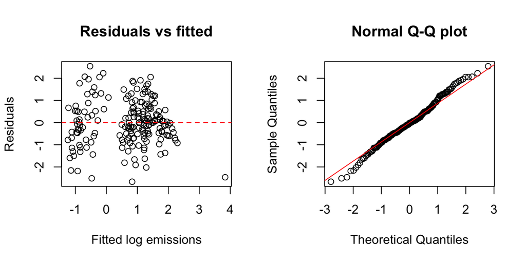

```r
par(mfrow = c(1, 2))
plot(
  fitted(model), resid(model),
  xlab = "Fitted log emissions",
  ylab = "Residuals",
  main = "Residuals vs fitted"
)
abline(h = 0, lty = 2, col = "red")
qqnorm(resid(model), main = "Normal Q-Q plot")
qqline(resid(model), col = "red")
```

```r
par(mfrow = c(1, 1))
```

## Conclusion and limitations

In this sample, density, annual population growth, and adjusted continent contrasts show evidence of association with 2019 per-capita CO2 emissions; the model does not find a statistically significant independent association for population size at the 5% level. The $R^2$ indicates that other country-level factors remain important.

The data are cross-sectional, countries may differ in omitted factors such as energy sources, industrial structure, and income, and the population characteristics are from 2022 while emissions are from 2019. The analysis therefore supports association statements only, and the time mismatch and unmeasured confounding limit interpretation. Results also apply only to countries with complete data in both files.